# IDS investigation worksheet

by GitChuds: Ethan, Miles, Freddie, Daniel & Zack

2026-10-28

**Note:** You can use this file as you ‘working document’ where you can try out various investigation ideas and keep notes about your findings. How you use and structure this file is up to you. It is recommended that you keep notes about what you are investigating and what you find as this will make the process of creating your presentation and report easier. Please note that you *do not* need to submit this file as part of your group project.

```r
library(tidyverse)
# Add any other libraries here
library(readr)
library(janitor)
library(ggplot2)
library(scales)
```

| Raw Variable Name | Clean Variable Name | Data Type | Numerical or Categorical | Description & Units |
| --- | --- | --- | --- | --- |
| **Date** | date | chr | categorical | date in year-month-day format |
| **Rented Bike Count** | rented_bike_count | dbl | numerical | count of bikes rented at each hour |
| **Hour** | hour | dbl | numerical | hour of the day |
| **Temperature** | temperature_c | dbl | numerical | temperature in Celsius |
| **Humidity** | humidity_percent | dbl | numerical | humidity in percentage |
| **Wind Speed** | wind_speed_m_s | dbl | numerical | wind speed in m/s |
| **Visibility** | visibility_10m | dbl | numerical | visibility in 10m units |
| **Dew Point Temperature** | dew_point_temperature_c | dbl | numerical | dew point temperature - temperature at which the air needs to be cooled to (at constant pressure) in order to achieve a relative humidity |
| **Solar Radiation** | solar_radiation_mj_m2 | dbl | numerical | solar radiation in MJ/M^2 |
| **Rainfall** | rainfall_mm | dbl | numerical | rainfall in mm |
| **Snowfall** | snowfall_cm | dbl | numerical | snowfall in cm |
| **Seasons** | seasons | chr | categorical | represents the four seasons |
| **Holiday** | holiday | chr | categorical | holiday or no holiday |
| **Functioning Day** | functioning_day | chr | categorical | yes or no; represents if system is fully operational or not (will be cleaned away) |

## Questions

1. Does temperature affect bike demand differently during peak commuting hours (8-9am and 6-7pm) compared to off-peak hours?
2. Is the holiday effect uniform across seasons, or do holiday demand patterns shift significantly between the seasons?
3. Is there a sharp threshold or non-linear drop-off point where precipitation severly degrades demand, or is the decay linear?
4. How do temperature and humidity combine to affect demand (compared to just considering temperature)?
5. How does the hourly distribution shift between a regular working day and a non-working day?

```r
# load data
seoul_bikes_raw <- read_csv("data/SeoulBikeData.csv", locale=locale(encoding="latin1"))
```

```r
#extracting raw data, locale needed to be specified as error otherwise.

#clean data
seoul_bikes <- seoul_bikes_raw |> clean_names()
#cleaning names to snake_case, as column headings' words initially separated with space

#looking above at the variable table, it might mean that on non-functional days, there will be no bikes rented whatsoever. We run the following code to verify:
#seoul_bikes |> filter(functioning_day == "No" & rented_bike_count > 0)
#from this, we realise that there are no

seoul_bikes <- seoul_bikes |> filter_out(functioning_day == "No") |>  subset(select = -functioning_day)
#after dropping non-functioning days, we can drop the functioning_day variable entirely, as it has become redundant. Code in comments below demonstrates this if there was no clean
#seoul_bikes |> ggplot(mapping = aes(x = functioning_day, y = rented_bike_count)) +
  #geom_col()

seoul_bikes
```

```
## # A tibble: 8,465 × 13
##    date    rented_bike_count  hour temperature_c humidity_percent wind_speed_m_s
##    <chr>               <dbl> <dbl>         <dbl>            <dbl>          <dbl>
##  1 01/12/…               254     0          -5.2               37            2.2
##  2 01/12/…               204     1          -5.5               38            0.8
##  3 01/12/…               173     2          -6                 39            1
##  4 01/12/…               107     3          -6.2               40            0.9
##  5 01/12/…                78     4          -6                 36            2.3
##  6 01/12/…               100     5          -6.4               37            1.5
##  7 01/12/…               181     6          -6.6               35            1.3
##  8 01/12/…               460     7          -7.4               38            0.9
##  9 01/12/…               930     8          -7.6               37            1.1
## 10 01/12/…               490     9          -6.5               27            0.5
## # ℹ 8,455 more rows
## # ℹ 7 more variables: visibility_10m <dbl>, dew_point_temperature_c <dbl>,
## #   solar_radiation_mj_m2 <dbl>, rainfall_mm <dbl>, snowfall_cm <dbl>,
## #   seasons <chr>, holiday <chr>
```

Initial Plots

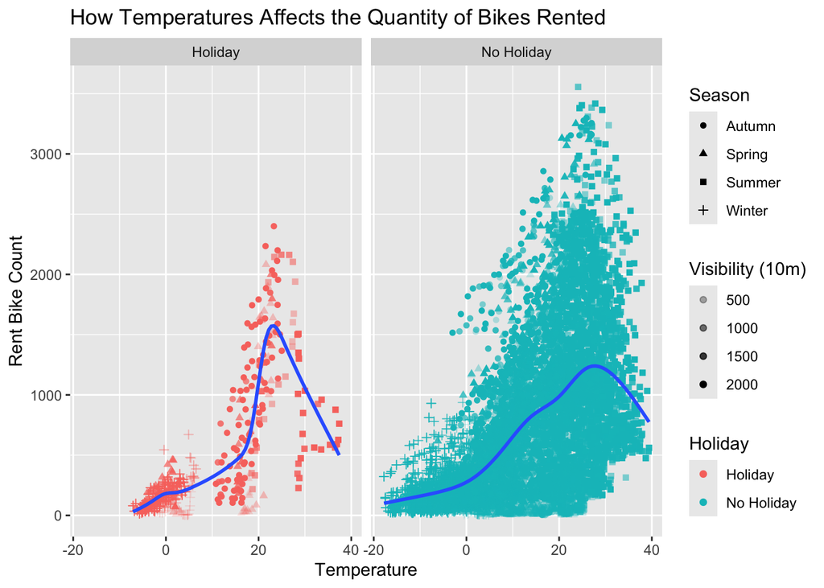

```r
seoul_bikes |>  ggplot(data = _, mapping = aes(x = temperature_c, y = rented_bike_count)) +
  geom_point(mapping = aes(color = holiday, alpha = visibility_10m, shape = seasons)) +
  geom_smooth(se = FALSE) +
  facet_wrap( ~ holiday) +
  labs(x = "Temperature",
       y = "Rent Bike Count",
       title = "How Temperatures Affects the Quantity of Bikes Rented",
       colour = "Holiday",
       shape = "Season",
       alpha = "Visibility (10m)"
      )
```

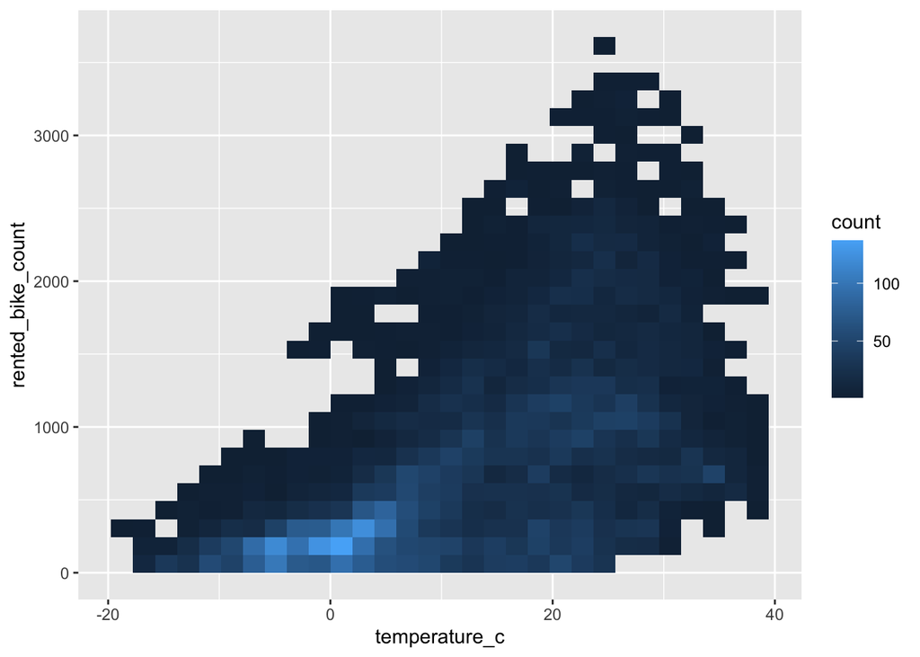

```r
#will need scaling later to make sure points are more visible

seoul_bikes |>  ggplot(data = _, mapping = aes(x = temperature_c, y = rented_bike_count)) +
  geom_bin_2d()
```

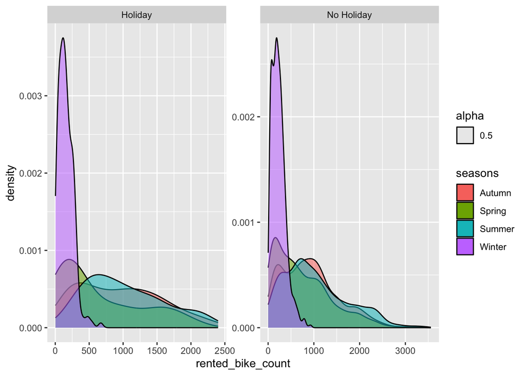

```r
seoul_bikes |> ggplot(data = _, mapping = aes(x = rented_bike_count, fill = seasons)) +
  geom_density(mapping = aes(alpha = 0.5)) +
  facet_wrap(~ holiday, scales = "free") +
  scale_y_continuous(labels = scales::comma)
```

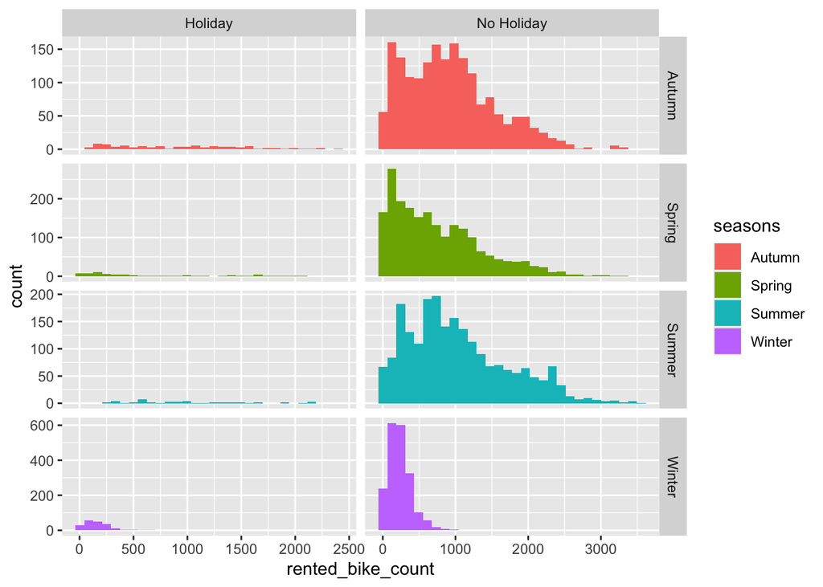

```r
seoul_bikes |> ggplot(data = _, mapping = aes(x = rented_bike_count, fill = seasons)) +
  geom_histogram(bins = 30) +
  facet_grid(seasons ~ holiday, scales = "free")
```

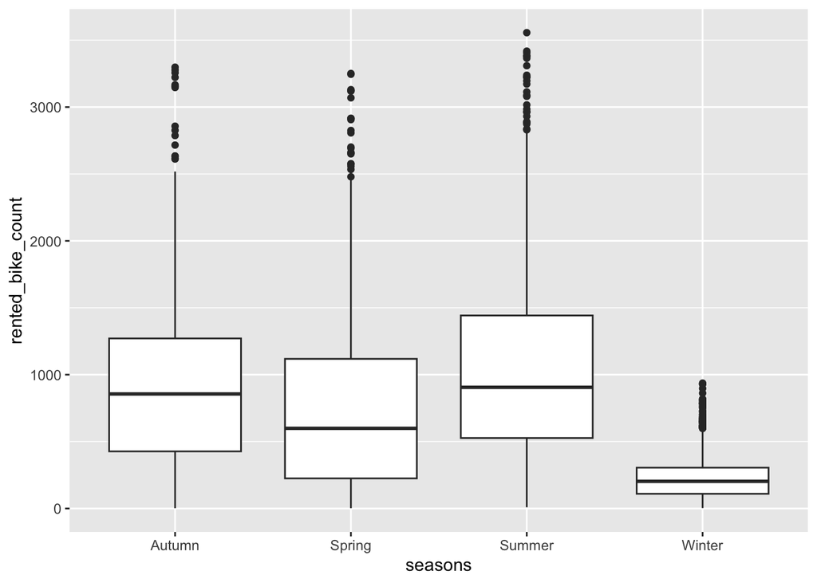

```r
seoul_bikes |> ggplot(data = _, mapping = aes(x = seasons, y = rented_bike_count)) +
  geom_boxplot()
```

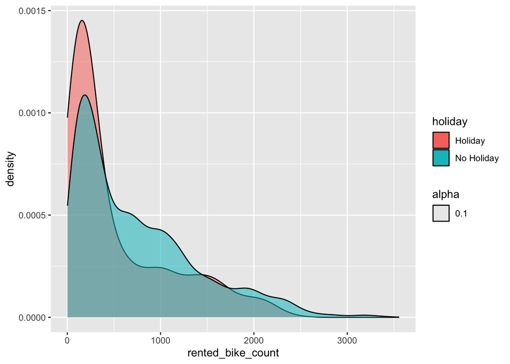

```r
seoul_bikes |> ggplot(mapping = aes(x = rented_bike_count, fill = holiday, alpha = 0.1)) +
  geom_density()
```

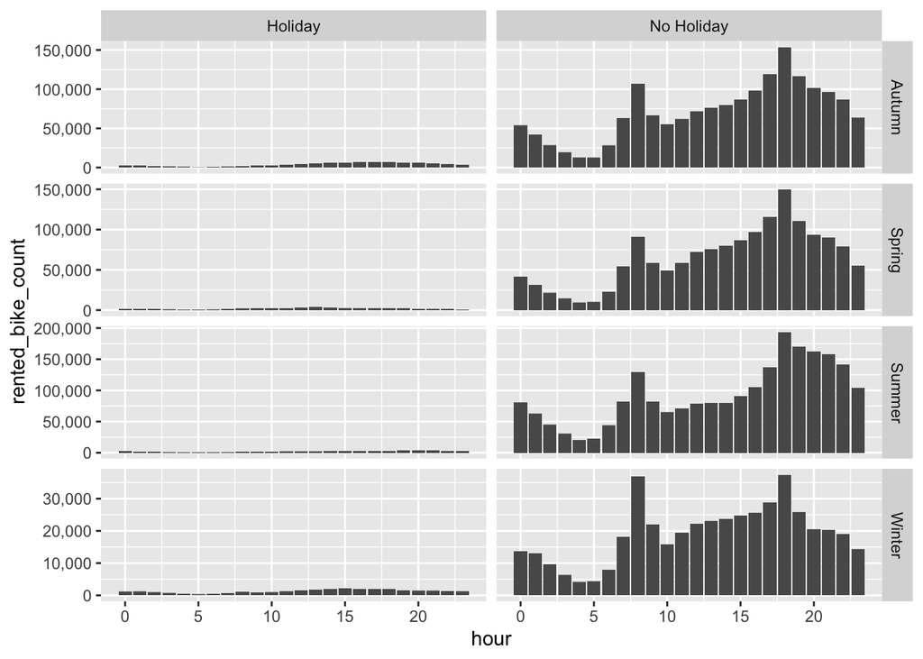

```r
seoul_bikes |> ggplot(mapping = aes(x = hour, y = rented_bike_count)) +
  geom_col() +
  facet_grid(seasons ~ holiday, scales = "free") +
  scale_y_continuous(labels = scales::comma)
```

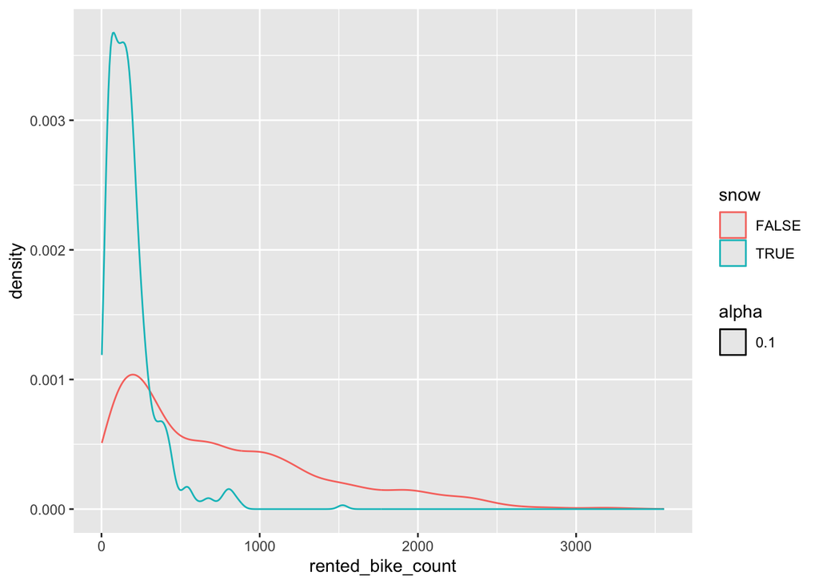

```r
seoul_bikes |> mutate(
  snow = ifelse(snowfall_cm == 0, FALSE, TRUE)
) |>
  ggplot(mapping = aes(x = rented_bike_count, color = snow, alpha = 0.1)) +
  geom_density() +
  scale_y_continuous(labels = scales::comma)
```

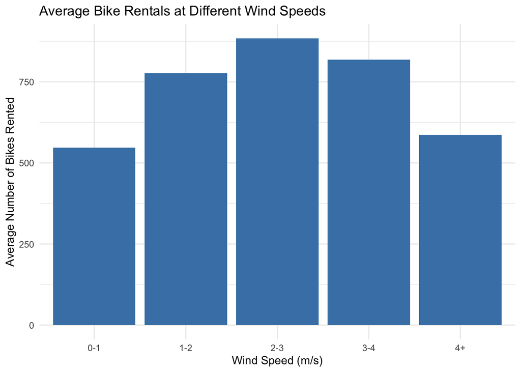

```r
seoul_bikes <- seoul_bikes %>%
  mutate(
    wind_group = cut(
      wind_speed_m_s,
      breaks = c(-Inf, 1, 2, 3, 4, Inf),
      labels = c("0-1", "1-2", "2-3", "3-4", "4+")
    )
  )

ggplot(seoul_bikes,
       aes(x = wind_group,
           y = rented_bike_count)) +
  stat_summary(
    fun = mean,
    geom = "col",
    fill = "steelblue"
  ) +
  labs(
    title = "Average Bike Rentals at Different Wind Speeds",
    x = "Wind Speed (m/s)",
    y = "Average Number of Bikes Rented"
  ) +
  theme_minimal()
```